# Лабораторная работа №4

Операционные системы

Лебеденко Е.В.

Российский университет дружбы народов, Москва, Россия

24 февраля 2026

# Информация

## Докладчик

- Лебеденко Елена Викторовна
- Студент НКАбд-04-25
- Российский университет дружбы народов
- 1032253535@rudn.ru

# Цель работы

Получение навыков правильной работы с репозиториями git.

# Задание

- Выполнить работу для тестового репозитория.
- Преобразовать рабочий репозиторий в репозиторий с git-flow и conventional commits.

# Теоретическое введение

- Gitflow Workflow опубликована и популяризована Винсентом Дриссеном.
- Gitflow Workflow предполагает выстраивание строгой модели ветвления с учётом выпуска проекта.
- Данная модель отлично подходит для организации рабочего процесса на основе релизов.
- Работа по модели Gitflow включает создание отдельной ветки для исправлений ошибок в рабочей среде.

# Выполнение лабораторной работы

Установка git-flow

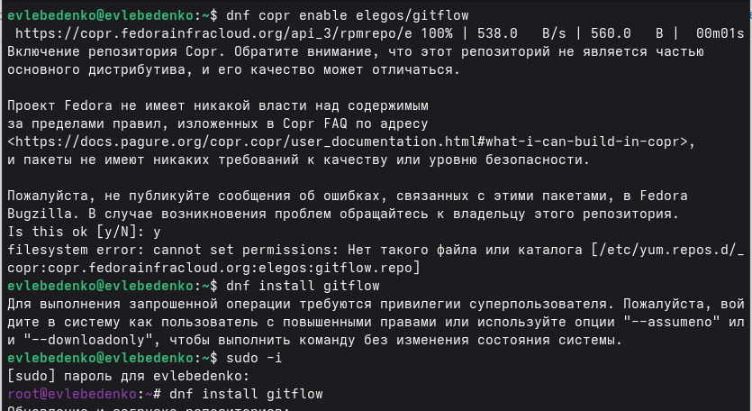

Установка git-flow

Установка Node.js

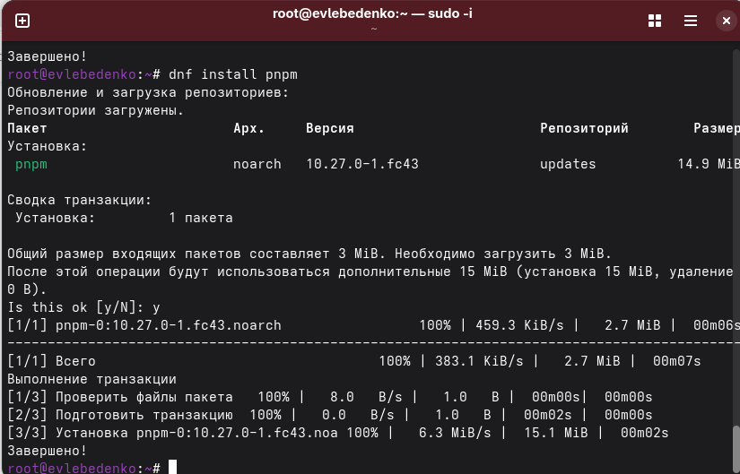

Установка Node.js

Настройка Node.js

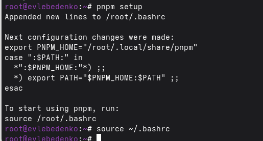

Настройка Node.js

Общепринятые коммиты

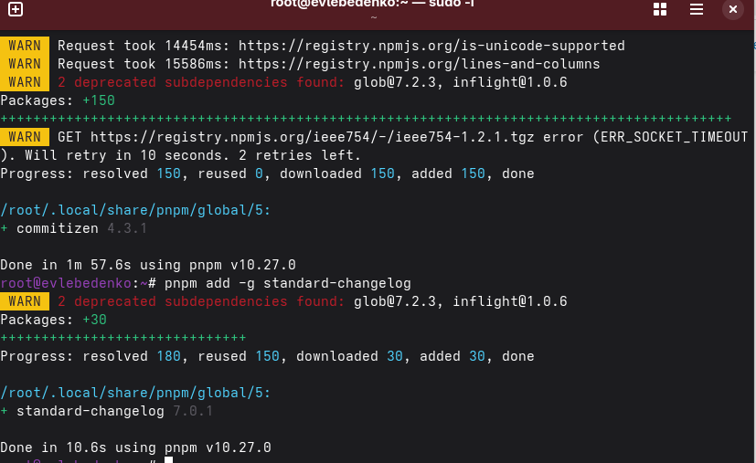

Общепринятые коммиты

## Практический сценарий использования git

Подключение репозитория к github

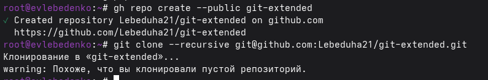

Репозиторий git-extended

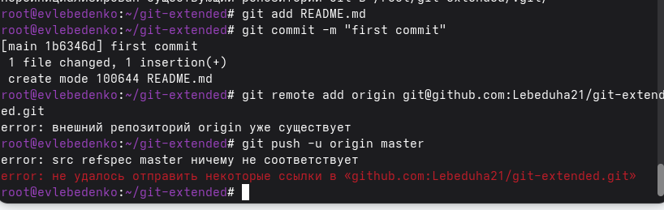

Первый коммит

Конфигурирую формат коммитов, добавляю новые файлы, выполняю коммит и отправляю его на github.

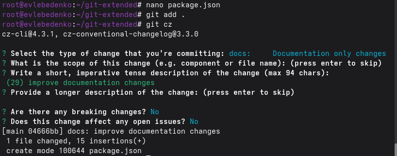

Конфигурация формата коммитов

Конфигурация git-flow

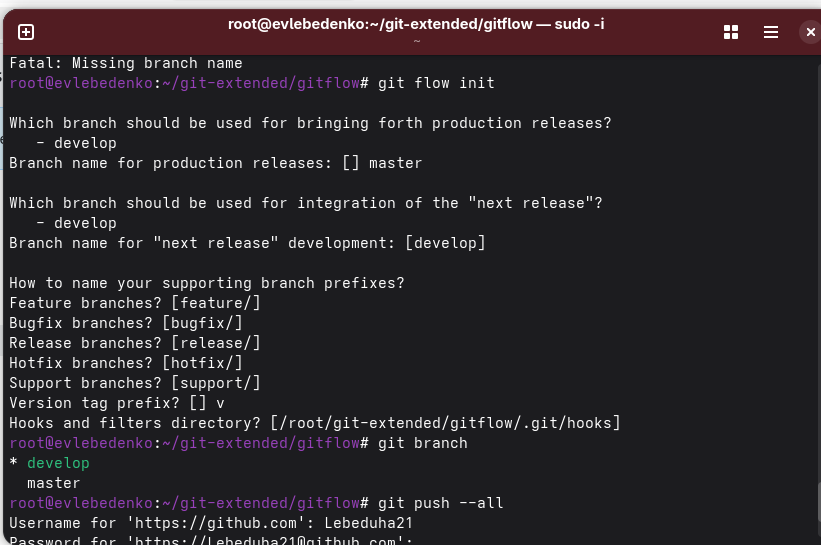

Конфигурация git-flow

Провожу манипуляции с релизом с версией 1.0.0

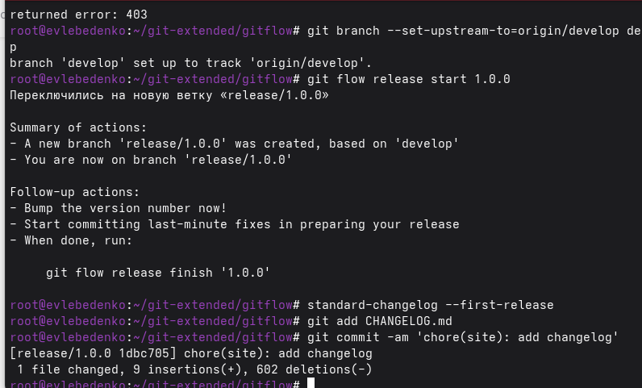

Манипуляции над релизом 1.0.0

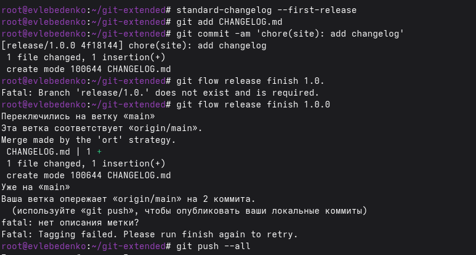

Изменяю релиз

Создаю релиз на github

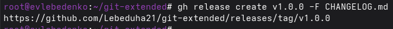

Релиз на github

Создаю релиз на github

## Работа с репозиторием git

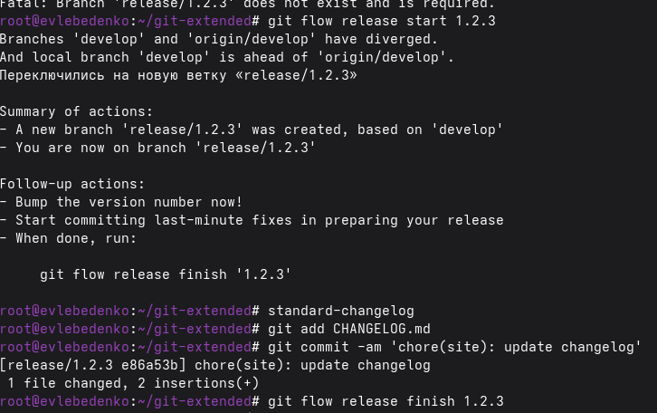

# Выводы

Во время выполнения лабораторной работы я получила навыки правильной работы с репозиториями git.